# Shiny apps

## Resources

- [Mastering Shiny](https://mastering-shiny.org/index.html)
- [Get started](https://shiny.posit.co/r/getstarted/shiny-basics/lesson1/)
- [Shiny tutorial](https://psyteachr.github.io/shiny-tutorials/01-first-app.html)
- [Shiny cheatsheet](https://rstudio.github.io/cheatsheets/html/shiny.html?_gl=1*10gjh72*_ga*OTY0NjQ3MzczLjE3NDM2MjA5ODU.*_ga_2C0WZ1JHG0*MTc0NTMyMDkwMy42LjEuMTc0NTMyMDk3MC4wLjAuMA..)
- [Shiny gallery](https://shiny.posit.co/r/gallery/)

## Today’s goals

Learn the concepts of

- What is a shiny app?
- Structure of a shiny app
- Widgets
- Reactivity
- Making your first shiny app
- Deploying

## What is a shiny app?

[figure not shown]

Shiny is a framework for creating web applications using R code. It is designed primarily with data scientists in mind, and to that end, you can create pretty complicated Shiny apps with no knowledge of HTML, CSS, or JavaScript.

## Structure of a shiny app

1. a user interface object
2. a server function
3. a call to the `shinyApp function`

```r
# Define UI ----
ui <- page_sidebar(

)

# Define server logic ----
server <- function(input, output) {

}

# Run the app ----
shinyApp(ui = ui, server = server)
```

## Structure of a shiny app - user interface

The user interface (ui) object controls the **layout and appearance** of your app.

```r
ui <- page_fluid(
  layout_sidebar(
    sidebar = sidebar("Sidebar"),
    "Main contents"
  )
)
```

[figure not shown]

## Structure of a shiny app - user interface

**Cards** are a common organizing unit for modern user interfaces. You can use the function `card()` to create a card in your Shiny app.

```r
ui <- page_sidebar(
  title = "title panel",
  sidebar = sidebar("Sidebar"),
  card()
)
```

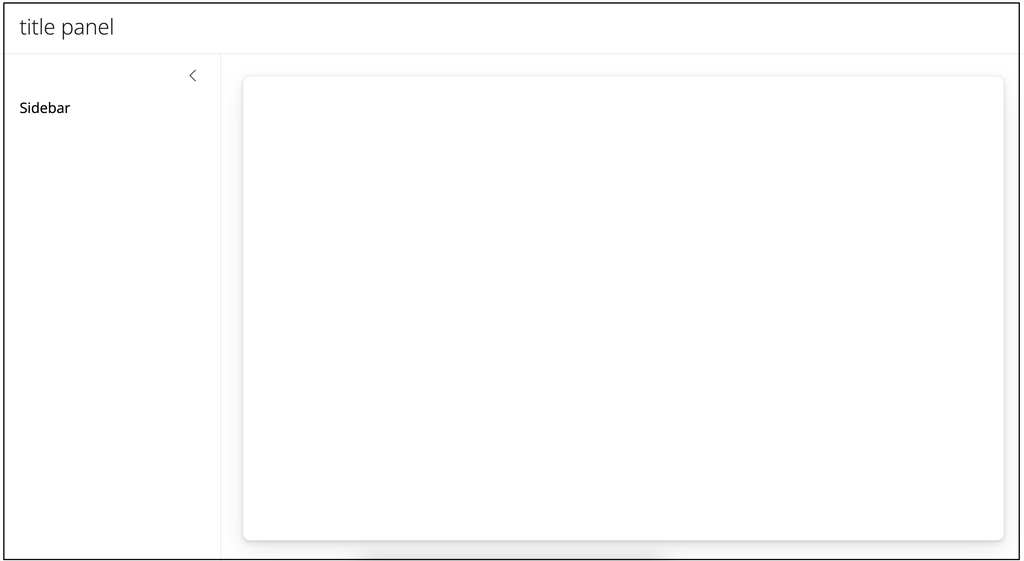

## Structure of a shiny app - user interface

You can also use functions like `card_header()`, `card_footer()`, and `card_image()` to add card elements to a card. For example, card_header() adds a header.

```r
ui <- page_sidebar(
  title = "title panel",
  sidebar = sidebar("Sidebar"),
  card(
    card_header("Card header"),
    "Card body"
  )
)
```

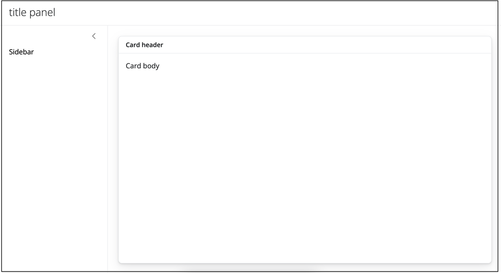

## Structure of a shiny app - server

The server function contains the instructions that your computer needs to build your app.

This is where we add reactive outputs, and will contain parts of R code we are familiar with, like ggplots.

```r
server <- function(input, output) {

  output$selected_var <- renderText({
    "You have selected this"
  })

}
```

## Widgets and reactivity

- **Widgets** are functions that allow users to interact with the dashboard. Widgets are specific in the **user interface** level.
- **Reactivity** happens using the inputs selected on the widget to create a certain output. Reactivity is specified at the **user interface** and **server** levels.

## Widgets

Shiny comes with a family of pre-built widgets, each created with a transparently named R function.

For example, Shiny provides a function named `actionButton` that creates an Action Button and a function named `sliderInput` that creates a slider bar.

## Widgets

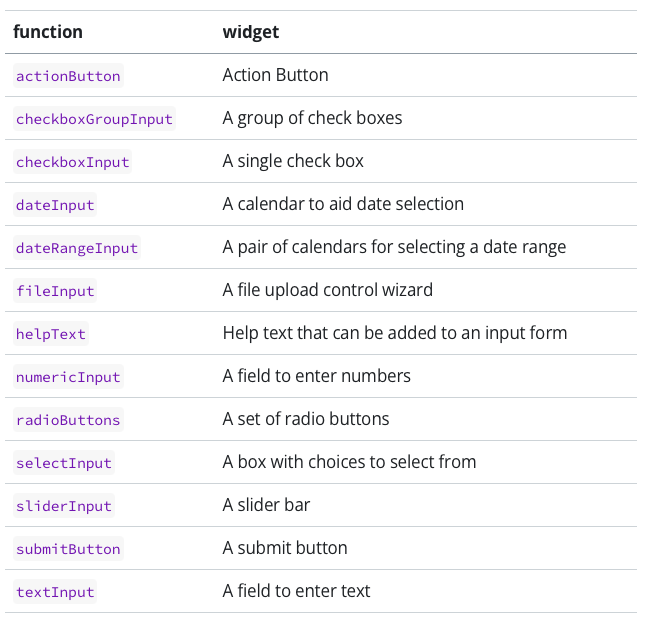

## Widgets - adding widgets

Each widget function requires several arguments. The first two arguments for each widget are

- a **name** for the widget: The user will not see this name, but you can use it to access the widget’s value. The name should be a character string.
- a **label**: This label will appear with the widget in your app. It should be a character string, but it can be an empty string ““.

In this example, the name is “action” and the label is “Action”:

`actionButton("action", label = "Action")`

## Reactivity - ui level

Shiny provides a family of functions that turn R objects into output for your user interface. Each function creates a specific type of output.

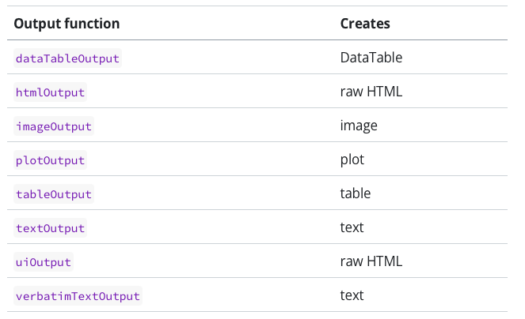

## Reactivity - server level

Use the render* function that corrresponds to the type of reactive object you are making.

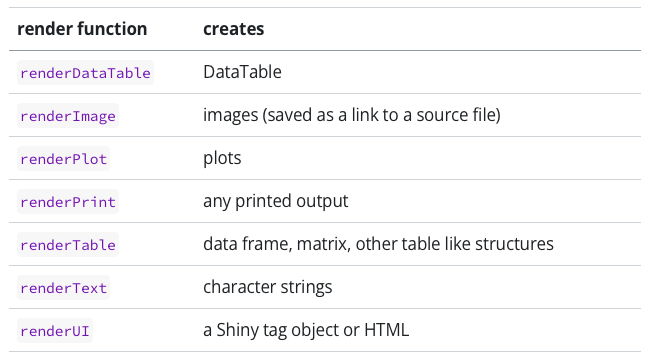

## Widgets and reactivity example

On the `ui` side, we use **widgets** (to allow user to interact with options) and **output functions** (to create a ui output into the server based on the widget selection).

```r
ui <- page_sidebar(
  title = "censusVis",
  sidebar = sidebar(
    helpText(
      "Create demographic maps with information from the 2010 US Census."
    ),
    selectInput(
      "var",
      label = "Choose a variable to display",
      choices =
        c("Percent White",
          "Percent Black",
          "Percent Hispanic",
          "Percent Asian"),
      selected = "Percent White"
    ),
    sliderInput(
      "range",
      label = "Range of interest:",
      min = 0,
      max = 100,
      value = c(0, 100)
    )
  ),
  textOutput("selected_var")
)
```

## Widgets and reactivity example

On the server side, we use render functions.

```r
server <- function(input, output) {

  output$selected_var <- renderText({
    paste("You have selected", input$var)
  })

}
```

## Making your first shiny app

Let’s make our first shiny app.

First, create a GitHub workflow named `15_shiny`.

Once you finish closing it, follow these steps to create your shiny app.

## Making your first shiny app

Go on `New` > `Shiny web app`

[figure not shown]

## Deploying

When it comes to sharing Shiny apps, you have two basic options:

- **Share your Shiny app as R scripts**. This is the simplest way to share an app, but it works only if your users have R on their own computer (and know how to use it). Users can use these scripts to launch the app from their own R session, just like you’ve been launching the apps so far in this tutorial.
- **Share your Shiny app as a web page**. This is definitely the most user friendly way to share a Shiny app. Your users can navigate to your app through the internet with a web browser. They will find your app fully rendered, up to date, and ready to go.

## Deploying as a webpage

Posit (formerly RStudio) offers three ways to host your Shiny app as a web page:

- **shinyapps.io**
- Shiny Server
- Posit Connect

## Deploying with shinyapps.io

- shinyapps.io lets you upload your app straight from your R session to a server hosted by Posit. You have complete control over your app including server administration tools.
- You’ll need to sign up for a free account.
- Then, you can deploy from within RStudio using the `Publish` button.

## Summary

In this exercise, we learned:

- What is a shiny app
- The structure of a shiny app
- How to add widgets and reactivity
- How to deploy an app